# Capstone Quiz I

Complete all **Exercises**, and submit answers to **Questions** on the Coursera platform.

This initial quiz will concern exploratory data analysis (EDA) of the Ames Housing dataset. EDA is essential when working with any source of data and helps inform modeling.

Packages:

```r
library(ggplot2)
library(dplyr)
library(statsr)
library(devtools)
```

First, let us load the data:

```r
load("ames_train.Rdata")
```

```r
sort(colSums(is.na(ames_train)), decreasing = TRUE)
```

```
##         Pool.QC    Misc.Feature           Alley           Fence    Fireplace.Qu
##             997             971             933             798             491
##    Lot.Frontage   Garage.Yr.Blt     Garage.Qual     Garage.Cond     Garage.Type
##             167              48              47              47              46
##   Garage.Finish       Bsmt.Qual       Bsmt.Cond   Bsmt.Exposure  BsmtFin.Type.1
##              46              21              21              21              21
##  BsmtFin.Type.2    Mas.Vnr.Area    BsmtFin.SF.1    BsmtFin.SF.2     Bsmt.Unf.SF
##              21               7               1               1               1
##   Total.Bsmt.SF  Bsmt.Full.Bath  Bsmt.Half.Bath     Garage.Cars     Garage.Area
##               1               1               1               1               1
##             PID            area           price     MS.SubClass       MS.Zoning
##               0               0               0               0               0
##        Lot.Area          Street       Lot.Shape    Land.Contour       Utilities
##               0               0               0               0               0
##      Lot.Config      Land.Slope    Neighborhood     Condition.1     Condition.2
##               0               0               0               0               0
##       Bldg.Type     House.Style    Overall.Qual    Overall.Cond      Year.Built
##               0               0               0               0               0
##  Year.Remod.Add      Roof.Style       Roof.Matl    Exterior.1st    Exterior.2nd
##               0               0               0               0               0
##    Mas.Vnr.Type      Exter.Qual      Exter.Cond      Foundation         Heating
##               0               0               0               0               0
##      Heating.QC     Central.Air      Electrical     X1st.Flr.SF     X2nd.Flr.SF
##               0               0               0               0               0
## Low.Qual.Fin.SF       Full.Bath       Half.Bath   Bedroom.AbvGr   Kitchen.AbvGr
##               0               0               0               0               0
##    Kitchen.Qual   TotRms.AbvGrd      Functional      Fireplaces     Paved.Drive
##               0               0               0               0               0
##    Wood.Deck.SF   Open.Porch.SF  Enclosed.Porch     X3Ssn.Porch    Screen.Porch
##               0               0               0               0               0
##       Pool.Area        Misc.Val         Mo.Sold         Yr.Sold       Sale.Type
##               0               0               0               0               0
##  Sale.Condition
##               0
```

```r
head(ames_train)
```

```
## # A tibble: 6 x 81
##        PID  area  price MS.SubClass MS.Zoning Lot.Frontage Lot.Area Street Alley
##      <int> <int>  <int>       <int> <fct>            <int>    <int> <fct>  <fct>
## 1   9.09e8   856 126000          30 RL                  NA     7890 Pave   <NA>
## 2   9.05e8  1049 139500         120 RL                  42     4235 Pave   <NA>
## 3   9.11e8  1001 124900          30 C (all)             60     6060 Pave   <NA>
## 4   5.35e8  1039 114000          70 RL                  80     8146 Pave   <NA>
## 5   5.34e8  1665 227000          60 RL                  70     8400 Pave   <NA>
## 6   9.08e8  1922 198500          85 RL                  64     7301 Pave   <NA>
## # ... with 72 more variables: Lot.Shape <fct>, Land.Contour <fct>,
## #   Utilities <fct>, Lot.Config <fct>, Land.Slope <fct>, Neighborhood <fct>,
## #   Condition.1 <fct>, Condition.2 <fct>, Bldg.Type <fct>, House.Style <fct>,
## #   Overall.Qual <int>, Overall.Cond <int>, Year.Built <int>,
## #   Year.Remod.Add <int>, Roof.Style <fct>, Roof.Matl <fct>,
## #   Exterior.1st <fct>, Exterior.2nd <fct>, Mas.Vnr.Type <fct>,
## #   Mas.Vnr.Area <int>, Exter.Qual <fct>, Exter.Cond <fct>, Foundation <fct>,
## #   Bsmt.Qual <fct>, Bsmt.Cond <fct>, Bsmt.Exposure <fct>,
## #   BsmtFin.Type.1 <fct>, BsmtFin.SF.1 <int>, BsmtFin.Type.2 <fct>,
## #   BsmtFin.SF.2 <int>, Bsmt.Unf.SF <int>, Total.Bsmt.SF <int>, Heating <fct>,
## #   Heating.QC <fct>, Central.Air <fct>, Electrical <fct>, X1st.Flr.SF <int>,
## #   X2nd.Flr.SF <int>, Low.Qual.Fin.SF <int>, Bsmt.Full.Bath <int>,
## #   Bsmt.Half.Bath <int>, Full.Bath <int>, Half.Bath <int>,
## #   Bedroom.AbvGr <int>, Kitchen.AbvGr <int>, Kitchen.Qual <fct>,
## #   TotRms.AbvGrd <int>, Functional <fct>, Fireplaces <int>,
## #   Fireplace.Qu <fct>, Garage.Type <fct>, Garage.Yr.Blt <int>,
## #   Garage.Finish <fct>, Garage.Cars <int>, Garage.Area <int>,
## #   Garage.Qual <fct>, Garage.Cond <fct>, Paved.Drive <fct>,
## #   Wood.Deck.SF <int>, Open.Porch.SF <int>, Enclosed.Porch <int>,
## #   X3Ssn.Porch <int>, Screen.Porch <int>, Pool.Area <int>, Pool.QC <fct>,
## #   Fence <fct>, Misc.Feature <fct>, Misc.Val <int>, Mo.Sold <int>,
## #   Yr.Sold <int>, Sale.Type <fct>, Sale.Condition <fct>
```

2. How many categorical variables are coded in R as having type `int`? Change them to factors when conducting your analysis.

   (answer)
   1. 0
   2. 1
   3. 2
   4. 3

```r
# type your code for Question 2 here, and Knit
# str(ames_train)
ames_train %>%
  select(is.numeric) %>%
  summary()
```

```
##       PID                 area          price         MS.SubClass
##  Min.   :5.263e+08   Min.   : 334   Min.   : 12789   Min.   : 20.00
##  1st Qu.:5.285e+08   1st Qu.:1092   1st Qu.:129763   1st Qu.: 20.00
##  Median :5.354e+08   Median :1411   Median :159467   Median : 50.00
##  Mean   :7.059e+08   Mean   :1477   Mean   :181190   Mean   : 57.15
##  3rd Qu.:9.071e+08   3rd Qu.:1743   3rd Qu.:213000   3rd Qu.: 70.00
##  Max.   :1.007e+09   Max.   :4676   Max.   :615000   Max.   :190.00
##
##   Lot.Frontage       Lot.Area       Overall.Qual     Overall.Cond
##  Min.   : 21.00   Min.   :  1470   Min.   : 1.000   Min.   :1.000
##  1st Qu.: 57.00   1st Qu.:  7314   1st Qu.: 5.000   1st Qu.:5.000
##  Median : 69.00   Median :  9317   Median : 6.000   Median :5.000
##  Mean   : 69.21   Mean   : 10352   Mean   : 6.095   Mean   :5.559
##  3rd Qu.: 80.00   3rd Qu.: 11650   3rd Qu.: 7.000   3rd Qu.:6.000
##  Max.   :313.00   Max.   :215245   Max.   :10.000   Max.   :9.000
##  NA's   :167
##    Year.Built   Year.Remod.Add  Mas.Vnr.Area     BsmtFin.SF.1
##  Min.   :1872   Min.   :1950   Min.   :   0.0   Min.   :   0.0
##  1st Qu.:1955   1st Qu.:1966   1st Qu.:   0.0   1st Qu.:   0.0
##  Median :1975   Median :1992   Median :   0.0   Median : 400.0
##  Mean   :1972   Mean   :1984   Mean   : 104.1   Mean   : 464.1
##  3rd Qu.:2001   3rd Qu.:2004   3rd Qu.: 160.0   3rd Qu.: 773.0
##  Max.   :2010   Max.   :2010   Max.   :1290.0   Max.   :2260.0
##                                NA's   :7        NA's   :1
##   BsmtFin.SF.2      Bsmt.Unf.SF     Total.Bsmt.SF     X1st.Flr.SF
##  Min.   :   0.00   Min.   :   0.0   Min.   :   0.0   Min.   : 334.0
##  1st Qu.:   0.00   1st Qu.: 223.5   1st Qu.: 797.5   1st Qu.: 876.2
##  Median :   0.00   Median : 461.0   Median : 998.0   Median :1080.5
##  Mean   :  48.07   Mean   : 547.0   Mean   :1059.2   Mean   :1157.1
##  3rd Qu.:   0.00   3rd Qu.: 783.0   3rd Qu.:1301.0   3rd Qu.:1376.2
##  Max.   :1526.00   Max.   :2336.0   Max.   :3138.0   Max.   :3138.0
##  NA's   :1         NA's   :1        NA's   :1
##   X2nd.Flr.SF     Low.Qual.Fin.SF   Bsmt.Full.Bath   Bsmt.Half.Bath
##  Min.   :   0.0   Min.   :   0.00   Min.   :0.0000   Min.   :0.00000
##  1st Qu.:   0.0   1st Qu.:   0.00   1st Qu.:0.0000   1st Qu.:0.00000
##  Median :   0.0   Median :   0.00   Median :0.0000   Median :0.00000
##  Mean   : 315.2   Mean   :   4.32   Mean   :0.4474   Mean   :0.06106
##  3rd Qu.: 688.2   3rd Qu.:   0.00   3rd Qu.:1.0000   3rd Qu.:0.00000
##  Max.   :1836.0   Max.   :1064.00   Max.   :3.0000   Max.   :2.00000
##                                     NA's   :1        NA's   :1
```

[output cut: 25 more lines]

```
##  Min.   :  0.000   Min.   :  0.00   Min.   :  0.000   Min.   :    0.00
##  1st Qu.:  0.000   1st Qu.:  0.00   1st Qu.:  0.000   1st Qu.:    0.00
##  Median :  0.000   Median :  0.00   Median :  0.000   Median :    0.00
##  Mean   :  3.118   Mean   : 14.77   Mean   :  1.463   Mean   :   45.81
##  3rd Qu.:  0.000   3rd Qu.:  0.00   3rd Qu.:  0.000   3rd Qu.:    0.00
##  Max.   :508.000   Max.   :440.00   Max.   :800.000   Max.   :15500.00
##
##     Mo.Sold          Yr.Sold
##  Min.   : 1.000   Min.   :2006
##  1st Qu.: 4.000   1st Qu.:2007
##  Median : 6.000   Median :2008
##  Mean   : 6.243   Mean   :2008
##  3rd Qu.: 8.000   3rd Qu.:2009
##  Max.   :12.000   Max.   :2010
##
```

3. In terms of price, which neighborhood has the highest standard deviation?
   1. (Answer)`StoneBr`
   2. `Timber`
   3. `Veenker`
   4. `NridgHt`

```r
# type your code for Question 3 here, and Knit
ames_train %>%
  group_by(Neighborhood) %>%
  summarise(std = sd(price)) %>%
  arrange(desc(std))
```

```
## # A tibble: 27 x 2
##    Neighborhood     std
##    <fct>          <dbl>
##  1 StoneBr      123459.
##  2 NridgHt      105089.
##  3 Timber        84030.
##  4 Veenker       72545.
##  5 Crawfor       71268.
##  6 GrnHill       70711.
##  7 Somerst       65199.
##  8 Edwards       54852.
##  9 CollgCr       52786.
## 10 SawyerW       48354.
## # ... with 17 more rows
```

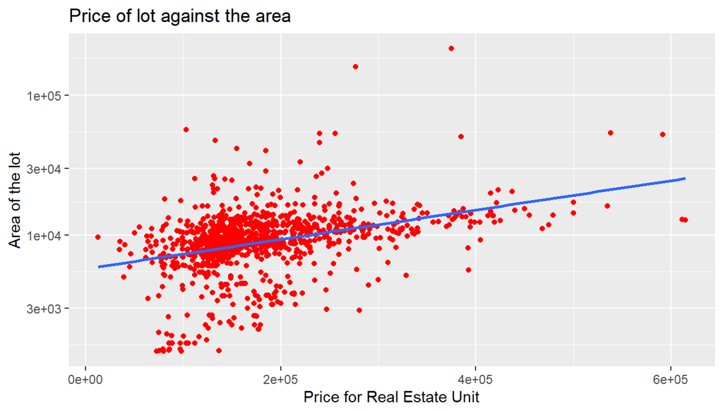

```r
# type your code for Question 4 here, and Knit
ames_train %>%
  ggplot(aes(x=price,y=Lot.Area)) +
  geom_point(color="red") +
  scale_y_log10() +
  geom_smooth(method=lm, se=FALSE) +
  labs(x = "Price for Real Estate Unit", y = "Area of the lot",
       title = "Price of lot against the area")
```

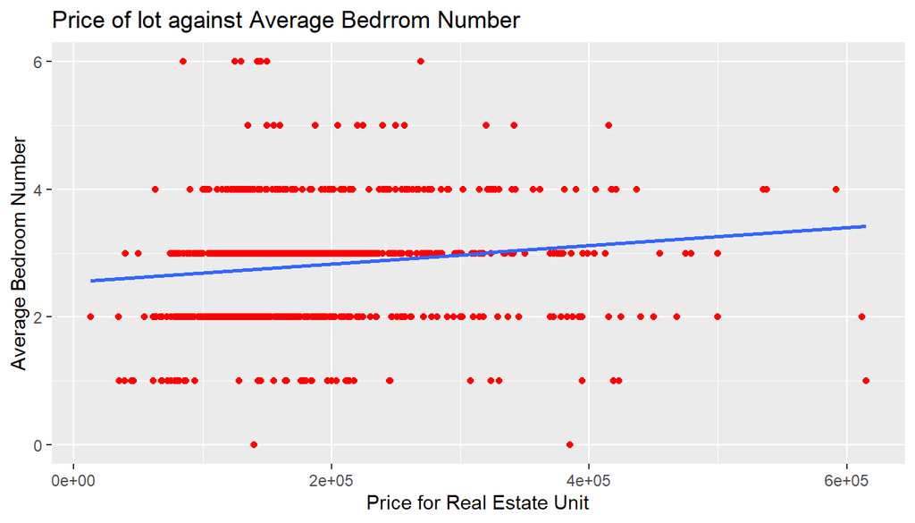

```r
ames_train %>%
  ggplot(aes(x=price,y=Bedroom.AbvGr)) +
  geom_point(color="red") +
  geom_smooth(method=lm, se=FALSE) +
  labs(x = "Price for Real Estate Unit", y = "Average Bedroom Number",
       title = "Price of lot against Average Bedrrom Number")
```

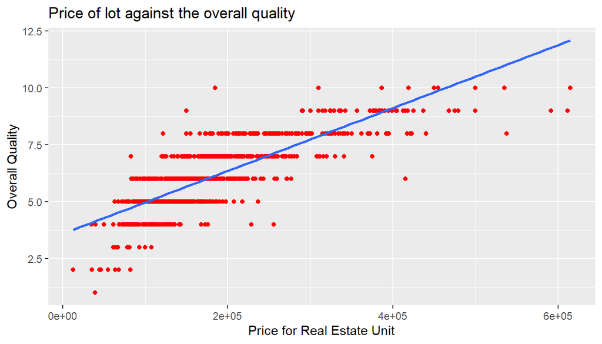

```r
ames_train %>%
  ggplot(aes(x=price,y=Overall.Qual)) +
  geom_point(color="red") +
  geom_smooth(method=lm, se=FALSE) +
  labs(x = "Price for Real Estate Unit", y = "Overall Quality",
       title = "Price of lot against the overall quality")
```

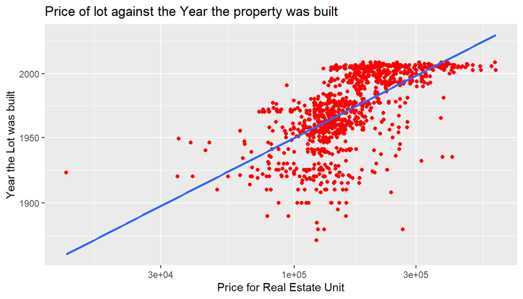

```r
ames_train %>%
  ggplot(aes(x=price,y=Year.Built)) +
  geom_point(color="red") +
  scale_y_log10() +
  scale_x_log10() +
  geom_smooth(method=lm, se=FALSE) +
  labs(x = "Price for Real Estate Unit", y = "Year the Lot was built",
       title = "Price of lot against the Year the property was built")
```

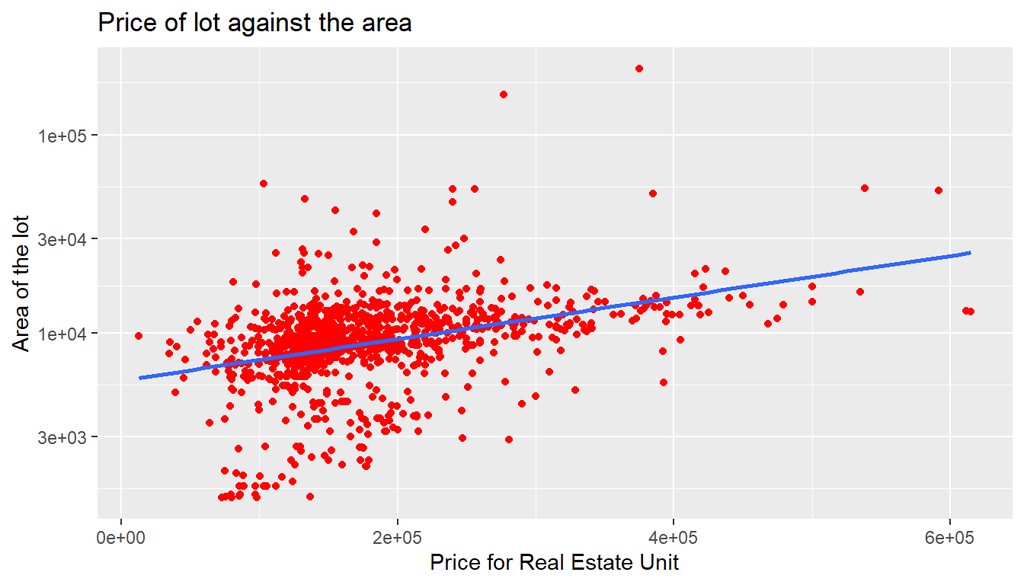

```r
# type your code for Question 5 here, and Knit
#It is better to log transform the area because it is not as variable and has high #number of outliers that are skewing the scatterplot.
ames_train %>%
  ggplot(aes(x=price,y=Lot.Area)) +
  geom_point(color="red") +
  scale_y_log10() +
  geom_smooth(method=lm, se=FALSE) +
  labs(x = "Price for Real Estate Unit", y = "Area of the lot",
       title = "Price of lot against the area")
```

```r
# type your code for Question 6 here, and Knit

table(ames_train$Garage.Cars >= 1)
```

```
##
## FALSE  TRUE
##    46   953
```

7. Which of the following statements is true about the dataset?
   1. Over 30 percent of houses were built after the year 1999.
   2. The median housing price is greater than the mean housing price.
   3. (answer) 21 houses do not have a basement.
   4. 4 houses are located on gravel streets.

```r
# type your code for Question 7 here, and Knit
table(ames_train$Year.Built > 1999)
```

```
##
## FALSE  TRUE
##   728   272
```

```r
median(ames_train$price) - mean(ames_train$price)
```

```
## [1] -21723.08
```

```r
table(ames_train$Total.Bsmt.SF > 0)
```

```
##
## FALSE  TRUE
##    21   978
```

```r
table(ames_train$Street)
```

```
##
## Grvl Pave
##    3  997
```

8. Test, at the $\alpha = 0.05$ level, whether homes with a garage have larger square footage than those without a garage.
   1. (answer) With a p-value near 0.000, we reject the null hypothesis of no difference.
   2. With a p-value of approximately 0.032, we reject the null hypothesis of no difference.
   3. With a p-value of approximately 0.135, we fail to reject the null hypothesis of no difference.
   4. With a p-value of approximately 0.343, we fail to reject the null hypothesis of no difference.

```r
# type your code for Question 8 here, and Knit
with(ames_train, t.test(area[Garage.Cars>0], area[Garage.Cars==0]))
```

```
##
##  Welch Two Sample t-test
##
## data:  area[Garage.Cars > 0] and area[Garage.Cars == 0]
## t = 5.134, df = 50.702, p-value = 4.535e-06
## alternative hypothesis: true difference in means is not equal to 0
## 95 percent confidence interval:
##  211.4183 482.9963
## sample estimates:
## mean of x mean of y
##  1492.251  1145.043
```

9. For homes with square footage greater than 2000, assume that the number of bedrooms above ground follows a Poisson distribution with rate $\lambda$. Your prior on $\lambda$ follows a Gamma distribution with mean 3 and standard deviation 1. What is your posterior mean and standard deviation for the average number of bedrooms in houses with square footage greater than 2000 square feet?
   1. Mean: 3.61, SD: 0.11
   2. (answer) Mean: 3.62, SD: 0.16
   3. Mean: 3.63, SD: 0.09
   4. Mean: 3.63, SD: 0.91

```r
# type your code for Question 9 here, and Knit
k = 9
theta = 1/3
ames_q9 = ames_train[ames_train$area > 2000, ]
k_star = k + sum(ames_q9$Bedroom.AbvGr)
theta_star <- theta / (length(ames_q9$Bedroom.AbvGr) * theta + 1)
post_mean <- k_star * theta_star
post_sd <- theta_star * sqrt(k_star)
post_mean
```

```
## [1] 3.617021
```

```r
post_sd
```

```
## [1] 0.1601644
```

10. When regressing $\log$(`price`) on $\log$(`area`), there are some outliers. Which of the following do the three most outlying points have in common?
    1. They had abnormal sale conditions.
    2. They have only two bedrooms.
    3. They have an overall quality of less than 3.
    4. (answer) They were built before 1930.

```r
# type your code for Question 10 here, and Knit
lm_q10 = lm(log(price) ~ log(area), ames_train)
res_q10 = resid(lm_q10) ** 2
threshold = sort(res_q10, partial=997)[997]
which(res_q10 > threshold)
```

```
## 206 428 741
## 206 428 741
```

```r
ames_train$Sale.Condition[c(206, 428, 741)]
```

```
## [1] Abnorml Abnorml Normal
## Levels: Abnorml AdjLand Alloca Family Normal Partial
```

```r
ames_train$Bedroom.AbvGr[c(206, 428, 741)]
```

```
## [1] 3 2 3
```

```r
ames_train$Overall.Qual[c(206, 428, 741)]
```

```
## [1] 4 2 4
```

```r
ames_train$Year.Built[c(206, 428, 741)]
```

```
## [1] 1910 1923 1920
```

11. Which of the following are reasons to log-transform `price` if used as a dependent variable in a linear regression?
    1. (answer) `price` is right-skewed.
    2. `price` cannot take on negative values.
    3. `price` can only take on integer values.
    4. Both a and b.

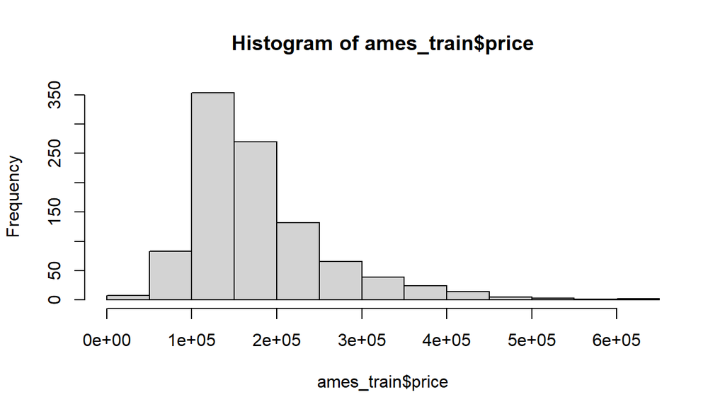

```r
# type your code for Question 11 here, and Knit
hist(ames_train$price)
```

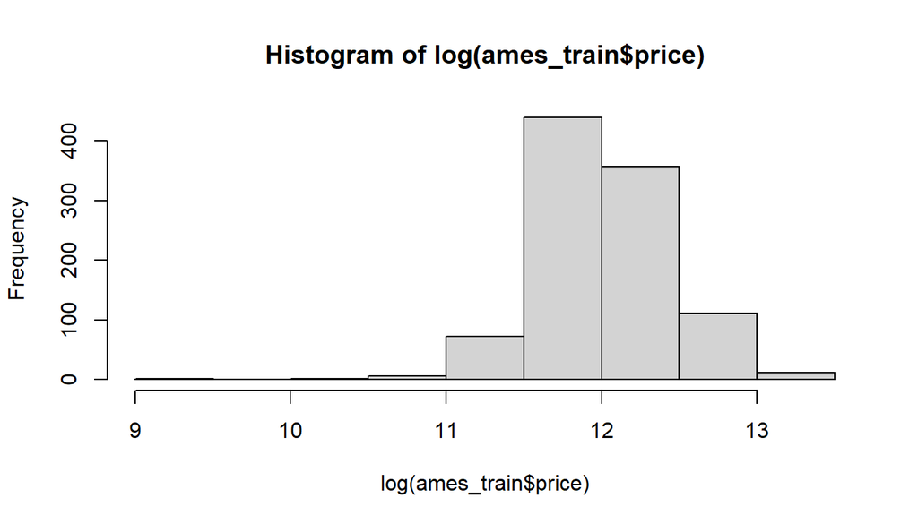

```r
hist(log(ames_train$price))
```

12. How many neighborhoods consist of only single-family homes? (e.g. `Bldg.Type` = `1Fam`)
    1. 0
    2. 1
    3. 2
    4. (answer)3

```r
# type your code for Question 12 here, and Knit

ames_train %>%
  group_by(Neighborhood) %>%
  summarise(flag=mean(Bldg.Type == '1Fam')) %>%
  arrange(-flag)
```

```
## # A tibble: 27 x 2
##    Neighborhood  flag
##    <fct>        <dbl>
##  1 ClearCr      1
##  2 NoRidge      1
##  3 Timber       1
##  4 Gilbert      0.980
##  5 BrkSide      0.976
##  6 NWAmes       0.976
##  7 CollgCr      0.965
##  8 IDOTRR       0.943
##  9 NAmes        0.923
## 10 Sawyer       0.918
## # ... with 17 more rows
```

13. Using color, different plotting symbols, conditioning plots, etc., does there appear to be an association between $\log$(`area`) and the number of bedrooms above ground (`Bedroom.AbvGr`)?
    1. (answer) Yes
    2. No

```r
# type your code for Question 13 here, and Knit

cor(ames_train$Bedroom.AbvGr, log(ames_train$area))
```

```
## [1] 0.5457625
```

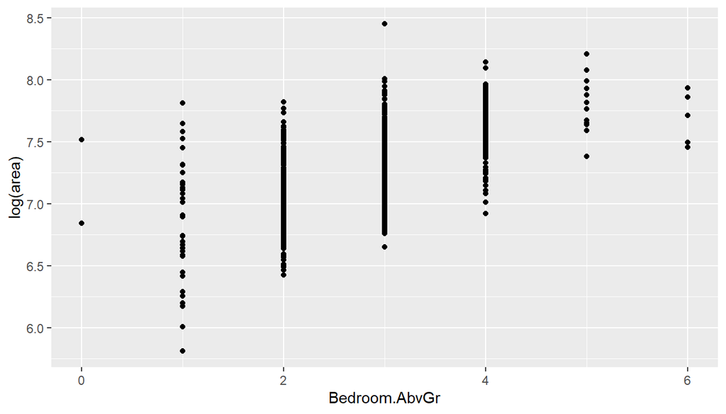

```r
ggplot(ames_train, aes(Bedroom.AbvGr, log(area))) + geom_point()
```

14. Of the people who have unfinished basements, what is the average square footage of the unfinished basement?
    1. 590.36
    2. (answer) 595.25
    3. 614.37
    4. 681.94

```r
# type your code for Question 14 here, and Knit
ames_train %>%
  filter(Bsmt.Unf.SF > 0) %>%
  summarise(mean(Bsmt.Unf.SF))
```

```
## # A tibble: 1 x 1
##   `mean(Bsmt.Unf.SF)`
##                 <dbl>
## 1                595.
```